# Projet 2 : Analysez des données de systèmes éducatifs

#### Potentiel : Evolution du pourcentage d'utilisateur d'internet par pays.

```python
selected_data=Stats_Data[Stats_Data['Country Name'].isin(win_countries)][Stats_Data['Indicator Code'].isin(indicateurs)]
```

```python
data_final = Stats_Data[Stats_Data['Country Name'].isin(selected_countries) & Stats_Data['Indicator Code'].isin(['SE.SEC.ENRL', 'SE.TER.ENRL', 'IT.NET.USER.P2'])]
```

```python
data_final_melt = data_final.melt(id_vars = ['Country Name', 'Country Code', 'Indicator Name', 'Indicator Code'], value_vars = ['1970', '1971', '1972', '1973', '1974', '1975', '1976', '1977', '1978',
       '1979', '1980', '1981', '1982', '1983', '1984', '1985', '1986', '1987',
       '1988', '1989', '1990', '1991', '1992', '1993', '1994', '1995', '1996',
       '1997', '1998', '1999', '2000', '2001', '2002', '2003', '2004', '2005',
       '2006', '2007', '2008', '2009', '2010', '2011', '2012', '2013', '2014',
       '2015', '2016', '2017', '2020', '2025', '2030', '2035', '2040', '2045',
       '2050', '2055', '2060', '2065', '2070', '2075', '2080', '2085', '2090',
       '2095', '2100'], var_name = 'Year', value_name = 'Value')
#data_final_melt
```

```python
data_final_melt['Year'] = data_final_melt['Year'].astype('int32')
```

```python
data_final_melt = data_final_melt[data_final_melt['Year'] > 1990]
#data_final_melt
```

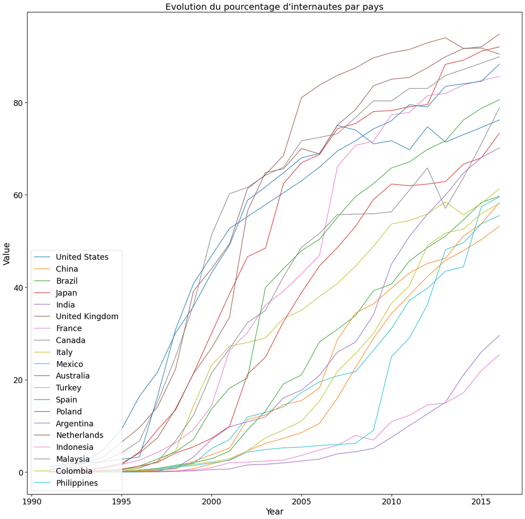

```python
plt.figure(figsize = (20,20))
for country in selected_countries:
    sns.lineplot(data_final_melt[data_final_melt['Indicator Code'] == 'IT.NET.USER.P2'][data_final_melt['Country Name'] == country ]['Year'],
            data_final_melt[data_final_melt['Indicator Code'] == 'IT.NET.USER.P2'][data_final_melt['Country Name'] == country ]['Value'])
plt.legend(selected_countries, loc = 'lower left', )
plt.title('Evolution du pourcentage d\'internautes par pays', size=20)
plt.show()
```

Les données ne nous donne pas directement d'information car le dataset ne nous fourni pas de prédiction. Cependant, on peut supposer :

- que les pays qui ont une tendance haussière importante du nombre d'étudiant et de personnes entre 15 et 64 ans, vont continuer à voir cette part croitre dans les prochaines années
- que les pays où internet est moins implanté vont continuer à voir l'utilisation d'internet augmenter, et donc le nombre de clients

#### Deuxième conclusion : Où est-il intéressant de s'implanter ?

Suite à cette seconde analyse, les pays qui sont intéressants pour le développement à l'internatonal sont : **les Etats-Unis, la Chine, le Brésil, le Japon, l'Inde et le Royaume-Uni**.

## Conclusion

### **Dans quels pays développer nos services en priorité ?**

Les pays qui ressortent de la première analyse sont : la Chine, l'Inde, les Etats-Unis, le Brésil et l'Indonésie.

Les pays qui ressortent de la deuxième analyse sont : les Etats-Unis, la Chine, le Brésil, le Japon, l'Inde et le Royaume-Unis.

En recoupant les résultats obtenus, il est possible de conclure qu'il serait intéressant de s'implanter en **Asie de l'Est et Pacific, en Asie du Sud, en Europe et Asie centrale, en Amérique du Nord et en Latin America & Caribbean**. Et plus particulièrement **en Chine, en Inde, aux Etats-Unis et au Brésil**.

### **Sur le Dataset**

L'étude de ce dataset est pertinente pour répondre à la problématique car il possède de nombreuses données pour comparer les pays :

- il y a les sources de chaque organisme pour les données récoltées
- Tous les pays du monde sont abordés dans cette étude
- Données de nature diverses : démographique, réussite aux examens, nombre d'inscriptions dans les études, taux d'utilisation d'internet.

Cependant, le dataset contient de nombreuses données manquantes et avec les données que nous donne ce dataset, il n'est pas possible de faire des projections pour les années à venir pour nos indicateurs choisis.

Il aurait été utile pour notre problématique de savoir le taux d'utilisation d'e-learning dans chaque pays pour affiner l'analyse.